# Gradient descent algorithm

Gradient descent is an iterative optimization algorithm for finding the minimize any function. To find a local minimum of a function using gradient descent, one takes steps proportional to the negative of the gradient of the function at the current point. If instead, one takes steps proportional to the positive of the gradient, one approaches a local maximum of that function. the procedure is then known as gradient ascent.

Gradient descent is also known as steepest descent.

## Some important terms-

#### eg. h(X) = theta[0] + theta[1]*X

here theta is coefficient of vector X and is a vector itself.

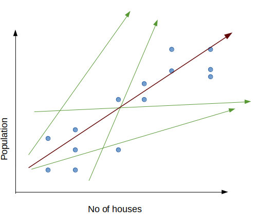

In the above diagram we could have many hypothesis functions. But all the green lines do not seem to fit the data well.

But the red line seems to fit data in the best possible way. The line that fits the data in best way, is decided by minimizing the cost function.

#### Cost function-

Cost function on minimization provides value of vector theta.

#### J(theta) = (sum(h(X)-Y)** 2)/2m

m-> no of examples

## Steps involved-

Here m denotes the number of examples in the training set.

1. Calcuation of the hypothesis h = X * theta
2. Calculation the cost = ((h-x)^2)/2m Some othe method can also be used to calculate the cost, in this case we are using mean square error function.
3. Calculation of the gradient = X' * loss / m
4. Updation of the parameters theta = theta - alpha * gradient
5. The gardient descent will stop when the gradient becomes 0 as at this point we get local minima.

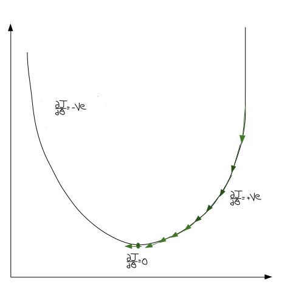

## Python implementation

#### Importing required modules

```python
import numpy as np
import random
```

#### Defining gradient descent fuction.

```python
def gradientDescent(x, y, theta, alpha, m, numIterations):
    xT = x.transpose()

    #Loop from 0  to number of iteration
    for i in range(0, numIterations):

        #defining hypothesis function and loss
        hypothesis = np.dot(x, theta)
        loss = hypothesis - y

        #Defining cost function
        cost = np.sum(loss ** 2) / (2 * m)

        #printing  no of iteration and cost for that iteration
        print("Iteration %d | Cost: %f" % (i, cost))
        # avg gradient per example
        gradient = np.dot(xT, loss) / m
        # simultaneous updation of theta
        theta = theta - alpha * gradient
    return theta


def dataGeneration(Points, bias, variance):
    x = np.zeros(shape=(Points, 2))
    y = np.zeros(shape=Points)

    for i in range(0, Points):
        # bias feature
        x[i][0] = 1
        x[i][1] = i
        y[i] = (i + bias) + random.uniform(0, 1) * variance
    return x, y

# generating 50 points with a bias of 20 and 10 variance as a bit of noise
x, y = dataGeneration(50, 20, 10)
m, n = np.shape(x)
numIterations= 50
alpha = 0.0003
theta = np.ones(n)
theta = gradientDescent(x, y, theta, alpha, m, numIterations)
```

```
Iteration 0 | Cost: 302.479294
Iteration 1 | Cost: 207.618962
Iteration 2 | Cost: 153.221724
Iteration 3 | Cost: 122.025743
Iteration 4 | Cost: 104.133202
Iteration 5 | Cost: 93.868761
Iteration 6 | Cost: 87.978221
Iteration 7 | Cost: 84.595646
Iteration 8 | Cost: 82.651121
Iteration 9 | Cost: 81.531165
Iteration 10 | Cost: 80.884012
Iteration 11 | Cost: 80.507962
Iteration 12 | Cost: 80.287360
Iteration 13 | Cost: 80.155893
Iteration 14 | Cost: 80.075535
Iteration 15 | Cost: 80.024485
Iteration 16 | Cost: 79.990239
Iteration 17 | Cost: 79.965630
Iteration 18 | Cost: 79.946547
Iteration 19 | Cost: 79.930634
Iteration 20 | Cost: 79.916539
Iteration 21 | Cost: 79.903487
Iteration 22 | Cost: 79.891034
Iteration 23 | Cost: 79.878925
Iteration 24 | Cost: 79.867015
Iteration 25 | Cost: 79.855219
Iteration 26 | Cost: 79.843489
Iteration 27 | Cost: 79.831798
Iteration 28 | Cost: 79.820131
Iteration 29 | Cost: 79.808477
Iteration 30 | Cost: 79.796831
Iteration 31 | Cost: 79.785192
Iteration 32 | Cost: 79.773557
Iteration 33 | Cost: 79.761925
Iteration 34 | Cost: 79.750295
Iteration 35 | Cost: 79.738668
Iteration 36 | Cost: 79.727043
Iteration 37 | Cost: 79.715419
Iteration 38 | Cost: 79.703798
Iteration 39 | Cost: 79.692178
Iteration 40 | Cost: 79.680560
Iteration 41 | Cost: 79.668944
Iteration 42 | Cost: 79.657330
Iteration 43 | Cost: 79.645718
Iteration 44 | Cost: 79.634107
Iteration 45 | Cost: 79.622498
Iteration 46 | Cost: 79.610891
Iteration 47 | Cost: 79.599286
Iteration 48 | Cost: 79.587682
Iteration 49 | Cost: 79.576081
```

```python
print(theta)
```

```
[1.1158684  1.73809886]
```